# Complex Network Analysis Graph

# CADDI AYYAD UNIVERSITY FACULTY OF SCIENCE SEMLALIA - MARRAKECH Data Science Master Degree

- EL HOUCINE ES SANHAJI
- elhoucineessanhaji@gmail.com
- Master of Data Science
- 2019/2020

## Required packages

```python
# pip install networkx
```

```python
# pip install matplotlib
```

```python
import networkx as nx
import matplotlib.pyplot as plt
%matplotlib inline
import warnings; warnings.simplefilter('ignore')
```

## Social Network Basics

Each network consists of:

- Nodes: The individuals whose network we are building.
- Edges: The connection between the nodes. It represents a relationship between the nodes of the network.

## Symmetric Networks (undirected)

The first network that we create is a group of people who work together. This is called a **symmetric network** because the relationship “working together” is a symmetric relationship: If A is related to B, B is also related to A.

```python
G_symmetric = nx.Graph()
```

```python
G_symmetric.add_edge('A', 'B')
G_symmetric.add_edge('A', 'D')
G_symmetric.add_edge('A', 'F')
G_symmetric.add_edge('A', 'C')
G_symmetric.add_edge('B', 'C')
G_symmetric.add_edge('C', 'F')
G_symmetric.add_edge('E', 'A')
G_symmetric.add_edge('E', 'B')
G_symmetric.add_edge('E', 'c')
G_symmetric.add_edge('d', 'B')
G_symmetric.add_edge('E', 'f')
```

```python
print(nx.info(G_symmetric))
```

```
Name:
Type: Graph
Number of nodes: 9
Number of edges: 11
Average degree:   2.4444
```

Now we visualize the network with the draw_networkx() function.

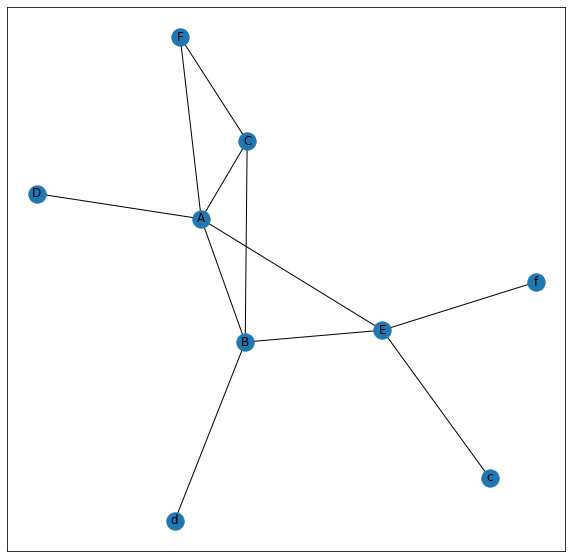

```python
plt.figure(figsize=(10,10))
nx.draw_networkx(G_symmetric);
```

## Asymmetric Networks (directed)

What if the relationship between nodes is ‘child of’, then the relationship is no longer symmetric. This is the case if someone follows someone else on Twitter. Or in the case of hyperlinks.  
If A is the child of B, then B is not a child of A. Such a network where the relationship is asymmetric (A is related to B, does not necessarily means that B is associated with A) is called an Asymmetric network.

```python
# We can build the asymmetric network in NetworkX using DiGraph method, which is short of Directional Graph.
G_asymmetric = nx.DiGraph()
G_asymmetric.add_edge('A','B')
G_asymmetric.add_edge('A','D')
G_asymmetric.add_edge('C','A')
G_asymmetric.add_edge('D','E')
```

To make sure that all nodes are distinctly visible in the network, we use the spring_layout() function, followed by the draw_networkx() function.

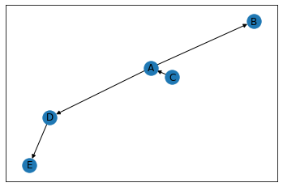

```python
nx.spring_layout(G_asymmetric)
nx.draw_networkx(G_asymmetric)
```

## Weighted Networks

It is possible that networks are made with weights, for example, if in our initial network we consider the number of projects done together as a weight, we will get a weighted Network.

Let us make one again of the employees, but this time we add weight to the network, each edge has a weight signifying the number of projects they have done together.

```python
G_weighted = nx.Graph()
```

```python
G_weighted.add_edge('A', 'B', weight=6)
G_weighted.add_edge('A', 'D', weight=2)
G_weighted.add_edge('A', 'F', weight=10)
G_weighted.add_edge('A', 'C', weight=17)
G_weighted.add_edge('B', 'C', weight=8)
G_weighted.add_edge('C', 'F', weight=3)
G_weighted.add_edge('E', 'A', weight=9)
G_weighted.add_edge('E', 'B', weight=45)
G_weighted.add_edge('E', 'c', weight=11)
G_weighted.add_edge('d', 'B', weight=5)
G_weighted.add_edge('E', 'f', weight=10)
```

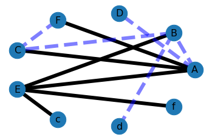

```python
elarge = [(u, v) for (u, v, d) in G_weighted.edges(data=True) if d['weight'] > 8]
esmall = [(u, v) for (u, v, d) in G_weighted.edges(data=True) if d['weight'] <= 8]

pos = nx.circular_layout(G_weighted)  # positions for all nodes

# nodes
nx.draw_networkx_nodes(G_weighted, pos, node_size=700)

# edges
nx.draw_networkx_edges(G_weighted, pos, edgelist=elarge, width=6)
nx.draw_networkx_edges(G_weighted, pos, edgelist=esmall, width=6, alpha=0.5, edge_color='b', style='dashed')

# labels
nx.draw_networkx_labels(G_weighted, pos, font_size=16, font_family='sans-serif')

plt.axis('off')
plt.show();
```

# Network Distance Measures

## Degree

Degree of a node defines the number of connections a node has. NetworkX has the function degree which we can use to determine the degree of a node in the network.

```python
nx.degree(G_symmetric, 'A')
```

```
5
```

## Distance

We can also determine the shortest path between two nodes and its length in NetworkX using **nx.shortest_path(Graph, Node1, Node2)** and **nx.shortest_path_length(Graph, Node1, Node2)** functions respectively.

```python
nx.shortest_path(G_symmetric, 'A', 'C')
```

```
['A', 'C']
```

```python
nx.shortest_path_length(G_symmetric, 'A', 'D')
```

```
1
```

```python
nx.dijkstra_path(G_symmetric, source='A', target='C')
```

```
['A', 'C']
```

## Breadth-first search

We can find the distance of a node from every other node in the network using breadth-first search algorithm, starting from that node. networkX provides the function bfs_tree to do it.  
And so if you use **M = nx.bfs_tree(G_symmetric, 'A')** and now draw this tree, we will get a network structure telling how we can reach other nodes of the network starting from A .

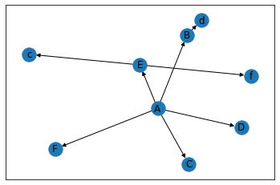

```python
S = nx.bfs_tree(G_symmetric, 'A')
nx.draw_networkx(S)
```

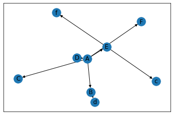

```python
M = nx.bfs_tree(G_symmetric, 'D')
nx.draw_networkx(M)
```

## Eccentricity

```python
nx.eccentricity(G_symmetric,'A')
```

```
2
```

```python
nx.eccentricity(G_symmetric,'B')
```

```
2
```

## Degree Centrality

The people most popular or more liked usually are the ones who have more friends.  
Degree centrality is a measure of the number of connections a particular node has in the network. It is based on the fact that important nodes have many connections. NetworkX has the function **degree_centrality()** to calculate the degree centrality of all the nodes of a network.

```python
nx.degree_centrality(G_symmetric)
```

```
{'A': 0.625,
 'B': 0.5,
 'D': 0.125,
 'F': 0.25,
 'C': 0.375,
 'E': 0.5,
 'c': 0.125,
 'd': 0.125,
 'f': 0.125}
```

## Eigenvector Centrality

It is not just how many individuals one is connected too, but the type of people one is connected with that can decide the importance of a node.  
Eigenvector centrality is a measure of how import a node is by accounting for the fact of how well it is connected to other important nodes.  
We can use the **eigenvector_centrality()** function of NetworkX to calculate eigenvector centrality of all the nodes in a network.  
The [Google’s Pagerank algorithm](https://en.wikipedia.org/wiki/PageRank) is a variant of Eigenvector centrality algorithm.

```python
nx.eigenvector_centrality(G_symmetric)
```

```
{'A': 0.5422628244759283,
 'B': 0.4656766038670999,
 'D': 0.16965188449051022,
 'F': 0.29742138301142584,
 'C': 0.40839397123178584,
 'E': 0.39210399053689454,
 'c': 0.12267418553508345,
 'd': 0.14569146197277402,
 'f': 0.12267418553508345}
```

## Closeness Centrality

Closeness Centrality is a measure where each node’s importance is determined by **closeness to all other nodes**.

```python
nx.closeness_centrality(G_symmetric)
```

```
{'A': 0.7272727272727273,
 'B': 0.6666666666666666,
 'D': 0.4444444444444444,
 'F': 0.47058823529411764,
 'C': 0.5333333333333333,
 'E': 0.6666666666666666,
 'c': 0.42105263157894735,
 'd': 0.42105263157894735,
 'f': 0.42105263157894735}
```

## Betweenness Centrality

The Betweenness Centrality is the centrality of control.

It represents the frequency at which a point occurs on the shortest paths that connected pair of points. It quantifies how many times a particular node comes in the shortest chosen path between two other nodes.

The nodes with high betweenness centrality play a significant role in the communication/information flow within the network.

The nodes with high betweenness centrality can have a strategic control and influence on others. An individual at such a strategic position can influence the whole group, by either withholding or coloring the information in transmission.

Networkx has the function **betweenness_centrality()** to measure it for the network. It has options to select if we want betweenness values to be normalized or not, weights to be included in centrality calculation or not, and to include the endpoints in the shortest path counts or not.

```python
nx.betweenness_centrality(G_symmetric)
```

```
{'A': 0.4464285714285714,
 'B': 0.30357142857142855,
 'D': 0.0,
 'F': 0.0,
 'C': 0.03571428571428571,
 'E': 0.46428571428571425,
 'c': 0.0,
 'd': 0.0,
 'f': 0.0}
```

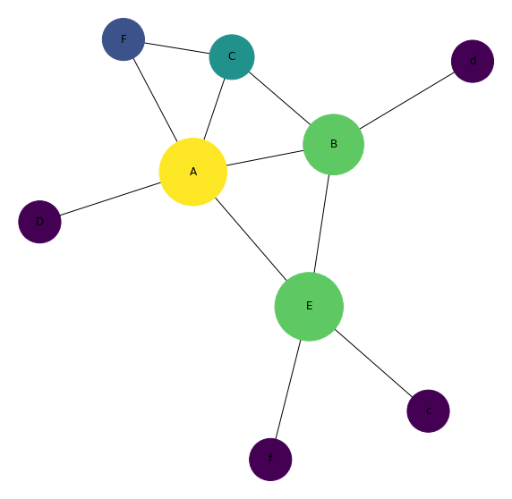

```python
pos = nx.spring_layout(G_symmetric)
betCent = nx.betweenness_centrality(G_symmetric, normalized=True, endpoints=True)
node_color = [20000.0 * G_symmetric.degree(v) for v in G_symmetric]
node_size =  [v * 10000 for v in betCent.values()]
plt.figure(figsize=(10,10))
nx.draw_networkx(G_symmetric, pos=pos, with_labels=True,
                 node_color=node_color,
                 node_size=node_size )
plt.axis('off');
```

```python
sorted(betCent, key=betCent.get, reverse=True)[:5]
```

```
['E', 'A', 'B', 'C', 'D']
```

# Case Study

```python
import pandas as pd
```

```python
df = pd.read_csv('Data.txt')
```

```python
df.shape
```

```
(3567, 1)
```

```python
df.info()
```

```
<class 'pandas.core.frame.DataFrame'>
RangeIndex: 3567 entries, 0 to 3566
Data columns (total 1 columns):
0 1    3567 non-null object
dtypes: object(1)
memory usage: 28.0+ KB
```

```python
df.tail()
```

|  | 0 1 |
| --- | --- |
| 3562 | 199 322 |
| 3563 | 199 324 |
| 3564 | 199 325 |
| 3565 | 199 342 |
| 3566 | 200 203 |

```python
G_fb = nx.read_edgelist("Data.txt", create_using = nx.Graph(), nodetype=int)
```

```python
print(nx.info(G_fb))
```

```
Name:
Type: Graph
Number of nodes: 1519
Number of edges: 3568
Average degree:   4.6978
```

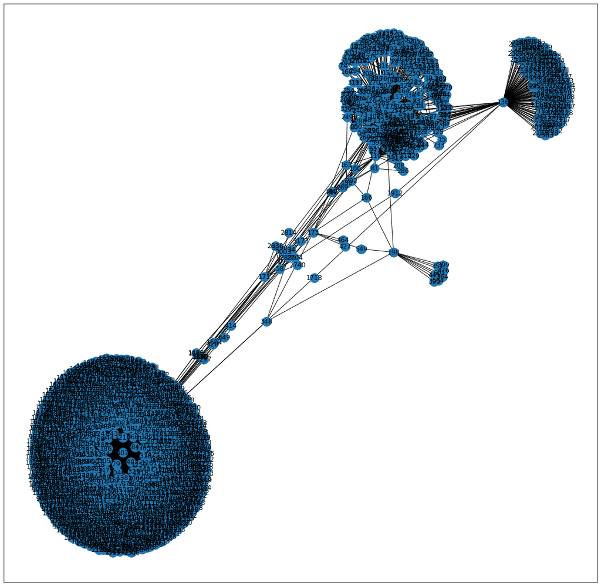

```python
plt.figure(figsize=(20,20))
nx.draw_networkx(G_fb);
```

We can also visualize the network such that the node color varies with Degree and node size with Betweenness Centrality. The code to do this is:

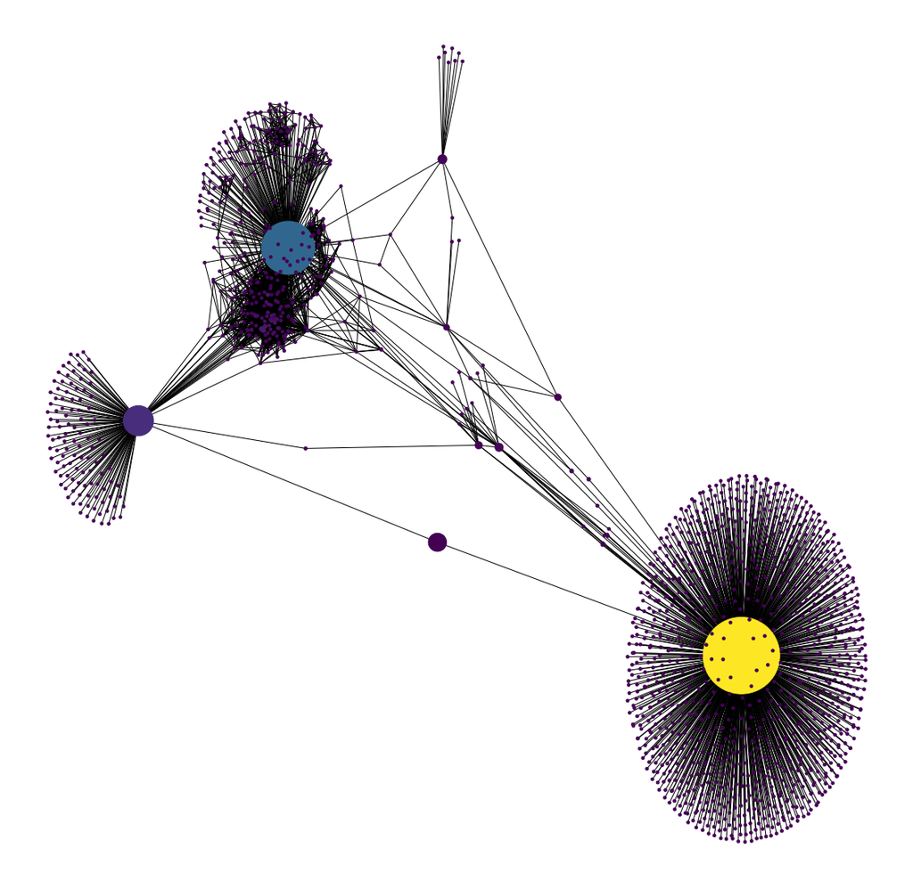

```python
pos = nx.spring_layout(G_fb)
betCent = nx.betweenness_centrality(G_fb, normalized=True, endpoints=True)
node_color = [20000.0 * G_fb.degree(v) for v in G_fb]
node_size =  [v * 10000 for v in betCent.values()]
plt.figure(figsize=(20,20))
nx.draw_networkx(G_fb, pos=pos, with_labels=False,
                 node_color=node_color,
                 node_size=node_size )
plt.axis('off');
```

You can also know the labels of the nodes with the highest betweenness centrality using:

```python
sorted(betCent, key=betCent.get, reverse=True)[:5]
```

```
[107, 0, 136, 1718, 198]
```

We can see that some nodes are common between Degree Centrality, which is a measure of degree, and Betweenness Centrality which controls the information flow.